# moleculaR: Spatial Probabilistic Mapping of Metabolites in Mass Spectrometry Imaging

Denis Abu Sammour & James-Lucas Cairns

2021-10-18

This is the Vignette for moleculaR.

# 1 Introduction

## 1.1 Accompanying data

For more info on how to properly include data into packages check [this page](https://r-pkgs.org/data.html).

**data** subdirectroy contains a pre-processed and analysis-ready RData file, containing everything needed to run an example or web-hosted shiny app. This will be included on the Github (not Git-synced).

**inst/extdata/** subdirectroy contains: (this will be part of the package but not synced by Git)  
* two txt file holding the url of the imzml (and ibd) in metaspace.  
* one tsv file containing one single continuous (full) spectrum (used for the accompanying example data).  
* one tsv file cotaning filtered swiss lipids database (used internally).  
* one csv file containing metaspace annotations for the example datase (used for the accompanying example data).

**data-external** subdirectroy contains: (this is only for development, not Git-synced and will be removed later)  
* two files; imzML and ibd, processed examplary MSI data.

**data-shinyWebHosted** subdirectroy is meant to contain processed ready-to-analyze data preferrably in .RData envirobnment type. This would ideally work with a web-hosted shiny app and will load RData on start. Please check [this page](https://shiny.rstudio.com/articles/persistent-data-storage.html) and let me know if this is actually an option. If they do not allow for data hosting we could always fetch the Github::moleculaR/data/RData file by downloading it and loading it into the session.

## 1.2 Package-app inputs/outputs

**[GUI Inputs]**  
**imzmlFile** string-browse, path to a single centroided (i.e. processed) imzML file.  
**spectrFile** string-browse, path to a single tsv file contianing a full continuous spectrum.  
*single analyte case*  
**queryMass** numeric-insert, m/z value. **probMapMethod** method used to generate the molecular probability map method.  
*collective projections case*  
**mtspc** string-browse, path to metaspace annotation file (.csv).  
**lipidSpecies** string-dropdown, values = `searchList$allClasses`

**[GUI Outputs]**  
**plot** fwhm as a function of m/z, generated after loading the single spectrum.  
*single analyte case* **image** ion image of the `queryMass`.  
**image** molecular probability map of the `queryMass`.

*collective projections case - if metaspace annotation file is not supplied*  
**image** collective probability map of all instances of the chosen `lipidSpecies`.

*collective projections case - if metaspace annotation file is provided*  
**image** collective probability map of confirmed instances of the chosen `lipidSpecies`.  
**console output** confirmed identifications.

# 2 Example workflow

## 2.1 Load data

```r
library(moleculaR)
######################
#### local input #####
######################

#// MSI data - either load a local file
imzmlFile         = "pathToFile.imzML"                # <-- browse input-selected locally i.e. file will be
                                                       # uploaded to the temp dir of R.

imzmlFile         = file.path(getwd(), "data-external", "pos-XIII-82492-msi.imzML") # temporary, just to test this nb

#// read the file into R
msData            = readCentrData(path = imzmlFile)    # would be nice to console-notify when done reading


#// single spectrum -  load a local tsv file
spectrFile        = "pathToFile.tsv"                  # <-- browse input-selected locally i.e. file will be
                                                       # uploaded to the temp dir of R.

spectrFile        = system.file("extdata", "pos-XIII-82492-singleSpectrum.tsv", package = "moleculaR", mustWork = TRUE)# temporary
msSpectr          = readSingleSpect(spectrFile)


#// load the processed swisslipids db internally
pathTosldb        = system.file("extdata", "swisslipids-speciesOnly-sep2020.tsv", package = "moleculaR", mustWork = TRUE)
sldb              = loadSwissDB(pathTosldb)


#// load the metaspace annotations file - supplied by user
pathToMtspc       = "pathToFile.csv"                  # <-- browse input-selected locally
pathToMtspc        = system.file("extdata", "metaspace_annotations.csv", package = "moleculaR", mustWork = TRUE) # temporary
mtspc             = read.csv(file = pathToMtspc, skip = 2,header = TRUE, colClasses = "character")
```

## 2.2 preprocessing of MS data

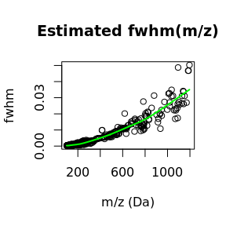

```r
#// estimate fwhm from msSpectr ----
fwhmFun           = estimateFwhm(s = msSpectr, plot = TRUE) # <-- this should be run directly after the spectrFile is
                                                            # uploaded, a plot is generated


# bin peaks
# -- notify at start  --#
msData            =  MALDIquant::binPeaks(msData,
                                           tolerance = fwhmFun(400)/400, #focusing on lipids
                                           method = "relaxed")
# -- notify when done --#


# filter out peaks which occur in less than 1% of the time - the
# built-in function of MALDIquant crashes for bigger datasets
# -- notify at start  --#
msData            = filterPeaks(x = msData, minFreq = 0.01)
```

```r
# -- notify when done --#


# normalization
# -- notify at start  --#
#msData            = foldChangeNorm(msData) <-- this is optional, no need for this
# -- notify when done --#


#// create spatial window
spwin             = spatstat::as.polygonal(spatstat::owin(mask = as.data.frame(MALDIquant::coordinates(msData))))


#// create sparse matrix representation
spmat             = createSparseMat(x = msData)

# End of preproccessing
```

## 2.3 Molecular Probability Maps (MPM)

```r
#// input by m/z value
queryMass         = 496.33972                                   # <-- input, numeric m/z value, use this as default value for exmaple
bwMethod          = "iterative"                                 # <-- input, c("iterative", "scott")

# NOTE: would be better to have two bwMethod inputs; one for one analyte case (defaults to "iterative") and one for
# collective projection case (defaults to "scott").
```

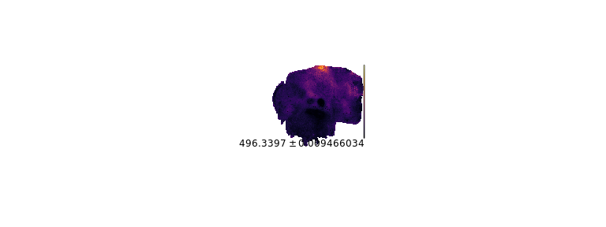

```r
#// output::ion image
s                 = MALDIquant::msiSlices(x = msData, center = queryMass,
                                          tolerance = (fwhmFun(queryMass) / 2.355) * 3)

if(sum(s, na.rm = T) == 0){
      par(mfrow = c(1, 1))
      #// image without masking
      spatstat::plot.owin(spwin,
                  main = paste0("No insances of m/z ", round(queryMass, 4), " were detected"),
                  ylim = rev(range(spwin$y)),
                  box = FALSE)
} else {

    MALDIquant::plotMsiSlice(x = s,
                             colRamp = colorRamp(viridis::viridis_pal(option = "inferno")(100)),
                             interpolate = F)

}
```

```r
#// output::molecular probability map
.uniqueMass       = as.numeric(spmat@Dimnames[[2]])


hits              = searchAnalyte(m = queryMass,
                                  fwhm = fwhmFun(queryMass),
                                  massAxis = .uniqueMass,
                                  spData = spmat,
                                  coords = MALDIquant::coordinates(msData))



#// check if hits is empty
# if(nrow(hits) == 0)
# {
#
#   par(mfrow = c(1, 1))
#   #// image without masking
#   spatstat::plot.owin(spwin,
#                   main = paste0("No insances of m/z ", round(queryMass, 4), " were detected"),
#                   ylim = rev(range(spwin$y)),
#                   box = FALSE)
#
# } else {
#
#   par(mfrow = c(1, 1))
#
#
#   #// create the spatial point pattern
#   hitsppp              = spatstat::ppp(x = hits$x,
#                                        y = hits$y,
#                                        window = spwin,
#                                        marks = hits[ , -c(1, 2)])
#
#
#   #// plotting
#
#   probImg              = probMap(hitsppp, bwMethod = bwMethod)
#
#
#   spatstat::plot.im(probImg$denspp,
#                     main = paste0("m/z ", round(queryMass, 4), " +/- ", round((fwhmFun(queryMass) / 2.355) * 3, 4)),
#                   col = spatstat::colourmap(viridis::viridis_pal(option = "inferno")(100), range = range(probImg$denspp, na.rm = T)),
#                   ylim = rev(range(spwin$y)),
#                   box = FALSE)
#   spatstat::plot.im(probImg$nonHotspotMask, col = rgb(0,0,0,0.3), add = TRUE)
# }
```

## 2.4 Collective Projection Maps (CPM)

The three different Collective Projection Maps (CPMs) that can be generted are:

1. Lipid Classes
2. Ion Milleu
3. Lipid Saturation

### 2.4.1 Lipid Classes

```r
#// filter sldb
Hidx = MALDIquant::match.closest(x = sldb$`Exact m/z of [M+H]+`,
                                 table = sort(as.numeric(mtspc$mz)),
                                 tolerance = fwhmFun(sldb$`Exact m/z of [M+H]+`))

Naidx = MALDIquant::match.closest(x = sldb$`Exact m/z of [M+Na]+`,
                                 table = sort(as.numeric(mtspc$mz)),
                                 tolerance = fwhmFun(sldb$`Exact m/z of [M+Na]+`))

kidx = MALDIquant::match.closest(x = sldb$`Exact m/z of [M+K]+`,
                                 table = sort(as.numeric(mtspc$mz)),
                                 tolerance = fwhmFun(sldb$`Exact m/z of [M+K]+`))



idxToKeep = c(which(!is.na(Hidx)), which(!is.na(Naidx)), which(!is.na(kidx)))

sldb = sldb[idxToKeep, ]

#// initialize the swisslipids database
searchList           = initLipidSearch(swissdb = sldb)

#// find peaks
.uniqueMass       = as.numeric(spmat@Dimnames[[2]])

for(lipidClass in names(searchList$lipidHits)){

searchList$lipidHits[[lipidClass]] = parallel::mclapply(X = seq(1, nrow(searchList$swissList[[lipidClass]])),
                                                          mc.cores = 1, FUN = function(i) {


       df            = data.frame(x = integer(0),
                            y = integer(0),
                            mass = numeric(0),
                            intensity = numeric(0),
                            adduct = character(0),
                            mode = character(0),
                            modeAdduct = character(0),
                            lipidID = character(0),
                            sumformula = character(0),
                            fullName = character(0),
                            abbrev = character(0),
                            numDoubleBonds = integer(0),
                            stringsAsFactors = F)

       msCoordinates = MALDIquant::coordinates(msData)




       #// protonated ----
       lipTmp        = searchList$swissList[[lipidClass]]$`Exact m/z of [M+H]+`[i]

              if(!is.na(lipTmp)) { # for example there is no protonated version of this lipid species

                       df     = rbind(df,
                                      searchLipid(m = lipTmp,
                                                  fwhm = fwhmFun(lipTmp),
                                                  massAxis = .uniqueMass,
                                                  spData = spmat,
                                                  coords = msCoordinates,
                                                  mtspc = mtspc, # <--
                                                  confirmedOnly = TRUE,
                                                  adduct = "H1",  # <--
                                                  mode = "positive",  # <--
                                                  modeAdduct = "M+H",  # <--
                                                  lipidID = searchList$swissList[[lipidClass]]$`Lipid ID`[i],
                                                  sumformula = searchList$swissList[[lipidClass]]$`Formula (pH7.3)`[i],
                                                  abbrev = searchList$swissList[[lipidClass]]$`Abbreviation*`[i],
                                                  numDoubleBonds = searchList$swissList[[lipidClass]]$numDoubleBond[i]))




              }


       #// Na+ adduct ----
       lipTmp               = searchList$swissList[[lipidClass]]$`Exact m/z of [M+Na]+`[i]

              if(!is.na(lipTmp)) { # for example there is no Na-adduct version


                       df     = rbind(df,
                                      searchLipid(m = lipTmp,
                                                  fwhm = fwhmFun(lipTmp),
                                                  massAxis = .uniqueMass,
                                                  spData = spmat,
                                                  coords = msCoordinates,
                                                  mtspc = mtspc, # <--
                                                  confirmedOnly = TRUE,
                                                  adduct = "Na1",  # <--
                                                  mode = "positive",  # <--
                                                  modeAdduct = "M+Na",  # <--
                                                  lipidID = searchList$swissList[[lipidClass]]$`Lipid ID`[i],
                                                  sumformula = searchList$swissList[[lipidClass]]$`Formula (pH7.3)`[i],
                                                  abbrev = searchList$swissList[[lipidClass]]$`Abbreviation*`[i],
                                                  numDoubleBonds = searchList$swissList[[lipidClass]]$numDoubleBond[i]))




              }


       #// K+ adduct ----
       lipTmp        = searchList$swissList[[lipidClass]]$`Exact m/z of [M+K]+`[i]

              if(!is.na(lipTmp)) { # for example there is no Na-adduct version

                       df     = rbind(df,
                                      searchLipid(m = lipTmp,
                                                  fwhm = fwhmFun(lipTmp),
                                                  massAxis = .uniqueMass,
                                                  spData = spmat,
                                                  coords = msCoordinates,
                                                  mtspc = mtspc, # <--
                                                  confirmedOnly = TRUE,
                                                  adduct = "K1",  # <--
                                                  mode = "positive",  # <--
                                                  modeAdduct = "M+K",  # <--
                                                  lipidID = searchList$swissList[[lipidClass]]$`Lipid ID`[i],
                                                  sumformula = searchList$swissList[[lipidClass]]$`Formula (pH7.3)`[i],
                                                  abbrev = searchList$swissList[[lipidClass]]$`Abbreviation*`[i],
                                                  numDoubleBonds = searchList$swissList[[lipidClass]]$numDoubleBond[i]))




              }


       return(df)
       })


#// merge
searchList$lipidHits[[lipidClass]] = do.call("rbind", searchList$lipidHits[[lipidClass]])
}
```

plotting all detections of a chosen lipid class

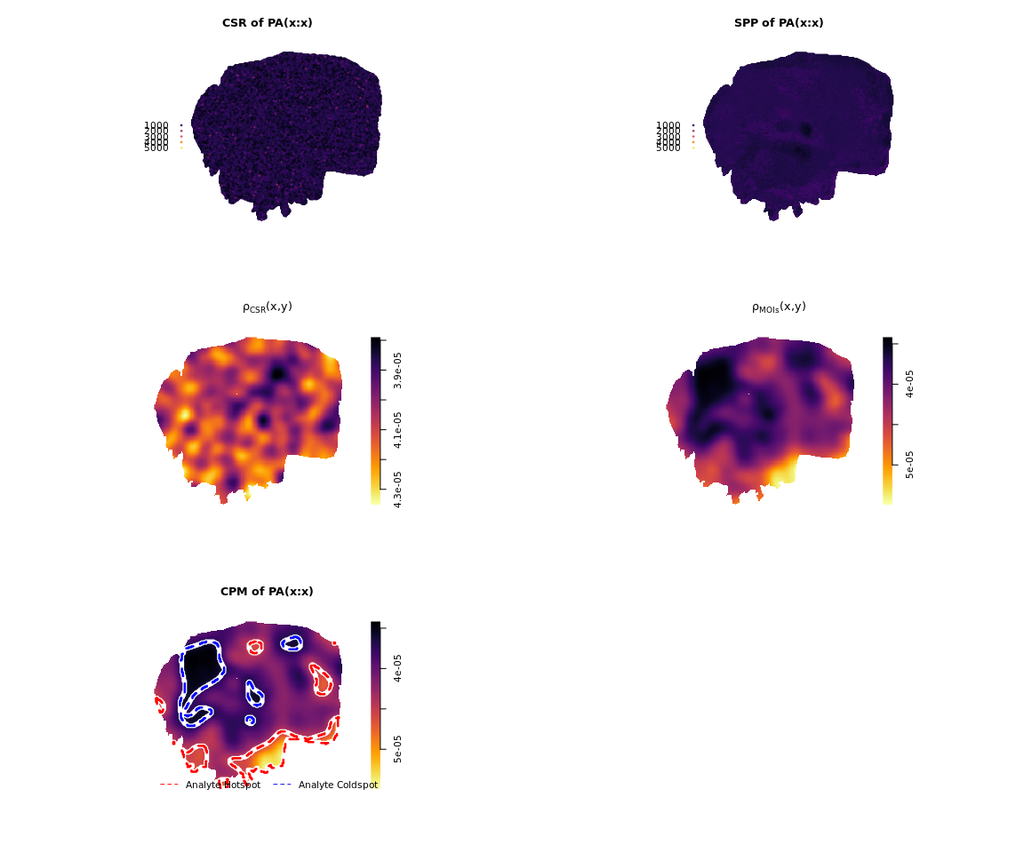

```r
#// choose one lipid species
lipidClass         = "PA(x:x)"                        # <-- Input, selection from drop-down, values = searchList$allClasses
bwMethod          = "scott"                           # fix that



if(is.null(searchList$lipidHits[[lipidClass]])) {



   par(mfrow = c(1, 1))

  #// empty window
  spatstat::plot.owin(spwin,
                  main = paste0("No insances of ", lipidClass, " were detected"),
                  ylim = rev(range(spwin$y)),
                  box = FALSE)


} else {


  sppCpm              = spatstat::ppp(x = searchList$lipidHits[[lipidClass]]$x,
                                     y = searchList$lipidHits[[lipidClass]]$y,
                                     window = spwin,
                                     marks = searchList$lipidHits[[lipidClass]][ , -c(1, 2)],
                                     checkdup = FALSE)

  sppCpm              = spatstat::as.ppp(sppCpm)

  probImg              = probMap(sppCpm, bwMethod = "scott", sqrtTansform = TRUE) # fixed arguments




  par(mfrow = c(3, 2))

# _________________________________________________ part one: CSR

colfun        = spatstat::colourmap(col = spatstat::to.transparent((viridis::viridis_pal(option = "inferno")(100)), 0.7),
                                      range = range(probImg$csrMoi$marks$intensity))

spatstat::plot.ppp(probImg$csrMoi, use.marks = TRUE, which.marks = "intensity",
                   ylim = rev(spwin$yrange),
                   main = paste0("CSR of ", lipidClass),
                   symap = spatstat::symbolmap(pch = 19,
                                   cols = colfun,
                                   size = 0.4,
                                   range = range(probImg$csrMoi$marks$intensity))) # colors according to intensity

# _________________________________________________ part two: SPP

colfun        = spatstat::colourmap(col = spatstat::to.transparent((viridis::viridis_pal(option = "inferno")(100)), 0.7),
                                      range = range(probImg$sppMoi$marks$intensity))

spatstat::plot.ppp(probImg$sppMoi, use.marks = TRUE, which.marks = "intensity",
                   ylim = rev(spwin$yrange),
                   main = paste0("SPP of ", lipidClass),
                   symap = spatstat::symbolmap(pch = 19,
                                   cols = colfun,
                                   size = 0.4,
                                   range = range(probImg$sppMoi$marks$intensity))) # colors according to intensity



# _________________________________________________ part three: rho of csr

spatstat::plot.im(probImg$rhoCsr,
                  main = expression(paste(rho["CSR"], "(x,y)")),
                col = spatstat::colourmap(viridis::viridis_pal(option = "inferno")(100), range = range(probImg$rhoCs, na.rm = T)),
                ylim = rev(range(spwin$y)),
                box = FALSE)


# _________________________________________________ part four: rho of MOI

spatstat::plot.im(probImg$rhoMoi,
                  main = expression(paste(rho["MOIs"], "(x,y)")),
                col = spatstat::colourmap(viridis::viridis_pal(option = "inferno")(100), range = range(probImg$rhoMoi, na.rm = T)),
                ylim = rev(range(spwin$y)),
                box = FALSE)





# _________________________________________________ part five : CPM

spatstat::plot.im(probImg$rhoMoi,
                  main = paste0("CPM of ", lipidClass),
                  col = spatstat::colourmap(viridis::viridis_pal(option = "inferno")(100), range = range(probImg$rhoMoi, na.rm = T)),
                  ylim = rev(range(spwin$y)),
                  box = FALSE)

spatstat::plot.owin(probImg$hotspotpp$window, col = rgb(1,1,1,0.0), border = "white", lwd = 5,  add = TRUE)
spatstat::plot.owin(probImg$hotspotpp$window, col = rgb(1,1,1,0.0), border = "red", lwd = 2.5, lty = "dashed",add = TRUE)

spatstat::plot.owin(probImg$coldspotpp$window, col = rgb(1,1,1,0.0), border = "white", lwd = 5,  add = TRUE)
spatstat::plot.owin(probImg$coldspotpp$window, col = rgb(1,1,1,0.0), border = "blue", lwd = 2.5, lty = "dashed",add = TRUE)

legend("bottom", legend = c("Analyte Hotspot", "Analyte Coldspot"), lty = c("dashed"),
       col = c("red", "blue"), bty = "n", horiz = TRUE)


}
```

### 2.4.2 Ion Milieu

```r
hitsList            = setNames(vector("list", 4), c("all", "M+K", "M+Na", "M+H"))

ionAdduct           = "" # input, dropdown



hitsList[["all"]]   = do.call("rbind", searchList$lipidHits[c("PC(x:x)",
                                                        "PE(x:x)",
                                                        "PI(x:x)",
                                                        "PS(x:x)",
                                                        "LPC(x:x)",
                                                        "LPE(x:x)",
                                                        "LPI(x:x)",
                                                        "LPS(x:x)")])


#hitsList[["all"]]   = hitsList[["all"]][hitsList[["all"]]$confirmed == TRUE, ]

hitsList[["all"]]   = spatstat::ppp(x = hitsList[["all"]]$x,
                                   y = hitsList[["all"]]$y,
                                   window = spwin,
                                   marks = hitsList[["all"]][ , -c(1, 2)],
                                   checkdup = FALSE)

hitsList[["all"]]   = spatstat::as.ppp(hitsList[["all"]])

hitsList[["M+K"]]     = spatstat::subset.ppp(hitsList[["all"]], modeAdduct == "M+K")
hitsList[["M+Na"]]    = spatstat::subset.ppp(hitsList[["all"]], modeAdduct == "M+Na")
hitsList[["M+H"]]     = spatstat::subset.ppp(hitsList[["all"]], modeAdduct == "M+H")

lipidSpecies         = "alkali-(lyso)GPLs"
```

input for the specific adduct

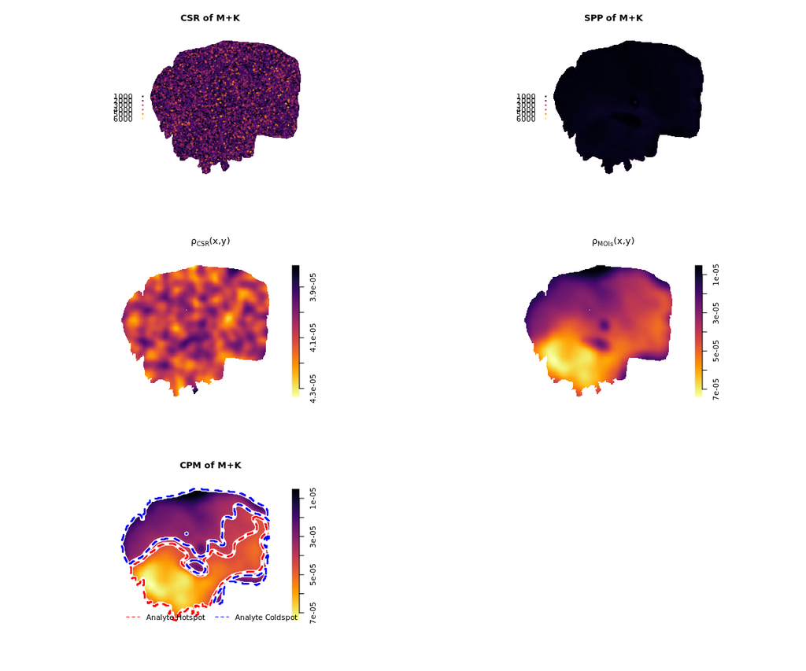

```r
igroup              = "M+K" # <- input, dropdown


if(hitsList[[igroup]]$n == 0) {



   par(mfrow = c(1, 1))

  #// empty window
  spatstat::plot.owin(spwin,
                  main = paste0("No insances of ", igroup, " were detected"),
                  ylim = rev(range(spwin$y)),
                  box = FALSE)


} else {

probImg    = probMap(hitsList[[igroup]], bwMethod = "scott", sqrtTansform = TRUE)




par(mfrow = c(3, 2))

# _________________________________________________ part one: CSR

colfun        = spatstat::colourmap(col = spatstat::to.transparent((viridis::viridis_pal(option = "inferno")(100)), 0.7),
                                      range = range(probImg$csrMoi$marks$intensity))

spatstat::plot.ppp(probImg$csrMoi, use.marks = TRUE, which.marks = "intensity",
                   ylim = rev(spwin$yrange),
                   #cols = viridis::viridis_pal(option = "inferno")(100),
                   #markscale = 0.000004,
                   #zap = 0.0,
                   #chars = 21,
                   main = paste0("CSR of ", igroup),
                   symap = spatstat::symbolmap(pch = 19,
                                   cols = colfun,
                                   size = 0.4,
                                   range = range(probImg$csrMoi$marks$intensity))) # colors according to intensity

# _________________________________________________ part two: SPP

colfun        = spatstat::colourmap(col = spatstat::to.transparent((viridis::viridis_pal(option = "inferno")(100)), 0.7),
                                      range = range(probImg$sppMoi$marks$intensity))

spatstat::plot.ppp(probImg$sppMoi, use.marks = TRUE, which.marks = "intensity",
                   ylim = rev(spwin$yrange),
                   #cols = viridis::viridis_pal(option = "inferno")(100),
                   #markscale = 0.000004,
                   #zap = 0.0,
                   #chars = 21,
                   main = paste0("SPP of ", igroup),
                   symap = spatstat::symbolmap(pch = 19,
                                   cols = colfun,
                                   size = 0.4,
                                   range = range(probImg$sppMoi$marks$intensity))) # colors according to intensity



# _________________________________________________ part three: rho of csr

spatstat::plot.im(probImg$rhoCsr,
                  main = expression(paste(rho["CSR"], "(x,y)")),
                col = spatstat::colourmap(viridis::viridis_pal(option = "inferno")(100), range = range(probImg$rhoCs, na.rm = T)),
                ylim = rev(range(spwin$y)),
                box = FALSE)


# _________________________________________________ part four: rho of MOI

spatstat::plot.im(probImg$rhoMoi,
                  main = expression(paste(rho["MOIs"], "(x,y)")),
                col = spatstat::colourmap(viridis::viridis_pal(option = "inferno")(100), range = range(probImg$rhoMoi, na.rm = T)),
                ylim = rev(range(spwin$y)),
                box = FALSE)





# _________________________________________________ part five : CPM

spatstat::plot.im(probImg$rhoMoi,
                  main = paste0("CPM of ", igroup),
                  col = spatstat::colourmap(viridis::viridis_pal(option = "inferno")(100), range = range(probImg$rhoMoi, na.rm = T)),
                  ylim = rev(range(spwin$y)),
                  box = FALSE)

spatstat::plot.owin(probImg$hotspotpp$window, col = rgb(1,1,1,0.0), border = "white", lwd = 5,  add = TRUE)
spatstat::plot.owin(probImg$hotspotpp$window, col = rgb(1,1,1,0.0), border = "red", lwd = 2.5, lty = "dashed",add = TRUE)

spatstat::plot.owin(probImg$coldspotpp$window, col = rgb(1,1,1,0.0), border = "white", lwd = 5,  add = TRUE)
spatstat::plot.owin(probImg$coldspotpp$window, col = rgb(1,1,1,0.0), border = "blue", lwd = 2.5, lty = "dashed",add = TRUE)

legend("bottom", legend = c("Analyte Hotspot", "Analyte Coldspot"), lty = c("dashed"),
       col = c("red", "blue"), bty = "n", horiz = TRUE)

}
```

### 2.4.3 Lipid Saturation

```r
hitsList            = setNames(vector("list", 5), c("all", "sat.", "mono.", "di.", "poly."))



hitsList[["all"]]   = do.call("rbind", searchList$lipidHits[c("PC(x:x)",
                                                        "PE(x:x)",
                                                        "PI(x:x)",
                                                        "PS(x:x)",
                                                        "LPC(x:x)",
                                                        "LPE(x:x)",
                                                        "LPI(x:x)",
                                                        "LPS(x:x)")])


hitsList[["all"]]   = spatstat::ppp(x = hitsList[["all"]]$x,
                                   y = hitsList[["all"]]$y,
                                   window = spwin,
                                   marks = hitsList[["all"]][ , -c(1, 2)],
                                   checkdup = FALSE)

hitsList[["all"]]   = spatstat::as.ppp(hitsList[["all"]])

hitsList[["sat."]]  = spatstat::subset.ppp(hitsList[["all"]], numDoubleBonds == 0L)
hitsList[["mono."]]  = spatstat::subset.ppp(hitsList[["all"]], numDoubleBonds == 1L)
hitsList[["di."]]  = spatstat::subset.ppp(hitsList[["all"]], numDoubleBonds == 2L)
hitsList[["poly."]]  = spatstat::subset.ppp(hitsList[["all"]], numDoubleBonds > 2L)

lipidSpecies         = "satrtn-(lyso)GPLs"
```

input for the specific adduct

[output not shown]

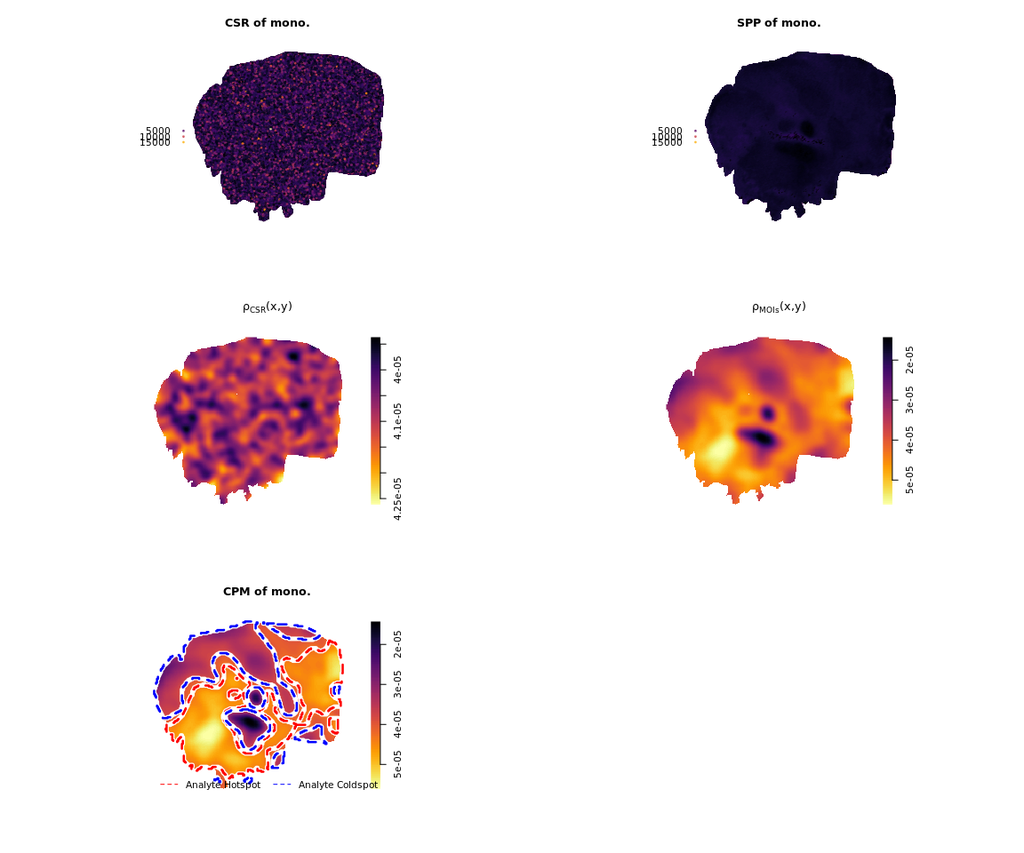

```r
igroup              = "mono." # <- input, dropdown


if(hitsList[[igroup]]$n == 0) {



   par(mfrow = c(1, 1))

  #// empty window
  spatstat::plot.owin(spwin,
                  main = paste0("No insances of ", igroup, " were detected"),
                  ylim = rev(range(spwin$y)),
                  box = FALSE)


} else {

probImg    = probMap(hitsList[[igroup]], bwMethod = "scott", sqrtTansform = TRUE)



  par(mfrow = c(3, 2))

# _________________________________________________ part one: CSR

colfun        = spatstat::colourmap(col = spatstat::to.transparent((viridis::viridis_pal(option = "inferno")(100)), 0.7),
                                      range = range(probImg$csrMoi$marks$intensity))

spatstat::plot.ppp(probImg$csrMoi, use.marks = TRUE, which.marks = "intensity",
                   ylim = rev(spwin$yrange),
                   #cols = viridis::viridis_pal(option = "inferno")(100),
                   #markscale = 0.000004,
                   #zap = 0.0,
                   #chars = 21,
                   main = paste0("CSR of ", igroup),
                   symap = spatstat::symbolmap(pch = 19,
                                   cols = colfun,
                                   size = 0.4,
                                   range = range(probImg$csrMoi$marks$intensity))) # colors according to intensity

# _________________________________________________ part two: SPP

colfun        = spatstat::colourmap(col = spatstat::to.transparent((viridis::viridis_pal(option = "inferno")(100)), 0.7),
                                      range = range(probImg$sppMoi$marks$intensity))

spatstat::plot.ppp(probImg$sppMoi, use.marks = TRUE, which.marks = "intensity",
                   ylim = rev(spwin$yrange),
                   #cols = viridis::viridis_pal(option = "inferno")(100),
                   #markscale = 0.000004,
                   #zap = 0.0,
                   #chars = 21,
                   main = paste0("SPP of ", igroup),
                   symap = spatstat::symbolmap(pch = 19,
                                   cols = colfun,
                                   size = 0.4,
                                   range = range(probImg$sppMoi$marks$intensity))) # colors according to intensity



# _________________________________________________ part three: rho of csr

spatstat::plot.im(probImg$rhoCsr,
                  main = expression(paste(rho["CSR"], "(x,y)")),
                col = spatstat::colourmap(viridis::viridis_pal(option = "inferno")(100), range = range(probImg$rhoCs, na.rm = T)),
                ylim = rev(range(spwin$y)),
                box = FALSE)


# _________________________________________________ part four: rho of MOI

spatstat::plot.im(probImg$rhoMoi,
                  main = expression(paste(rho["MOIs"], "(x,y)")),
                col = spatstat::colourmap(viridis::viridis_pal(option = "inferno")(100), range = range(probImg$rhoMoi, na.rm = T)),
                ylim = rev(range(spwin$y)),
                box = FALSE)





# _________________________________________________ part five : CPM

spatstat::plot.im(probImg$rhoMoi,
                  main = paste0("CPM of ", igroup),
                  col = spatstat::colourmap(viridis::viridis_pal(option = "inferno")(100), range = range(probImg$rhoMoi, na.rm = T)),
                  ylim = rev(range(spwin$y)),
                  box = FALSE)

spatstat::plot.owin(probImg$hotspotpp$window, col = rgb(1,1,1,0.0), border = "white", lwd = 5,  add = TRUE)
spatstat::plot.owin(probImg$hotspotpp$window, col = rgb(1,1,1,0.0), border = "red", lwd = 2.5, lty = "dashed",add = TRUE)

spatstat::plot.owin(probImg$coldspotpp$window, col = rgb(1,1,1,0.0), border = "white", lwd = 5,  add = TRUE)
spatstat::plot.owin(probImg$coldspotpp$window, col = rgb(1,1,1,0.0), border = "blue", lwd = 2.5, lty = "dashed",add = TRUE)

legend("bottom", legend = c("Analyte Hotspot", "Analyte Coldspot"), lty = c("dashed"),
       col = c("red", "blue"), bty = "n", horiz = TRUE)
}
```

# 3 Shiny App Usage

## 3.1 Loading the Data & Preprocessing

This step just applies to the package-app.R, since the example-app.R skips this step of Loading & Preprocessing Data for demonstration purposes.

1. The first step using the shiny package-app, would be to upload you own data. To do this click on imzML & ibd File and navigate to the directory containing the files you want to upload. Then select both imzML- and ibd-Files and upload them.
2. Press Spectrum .tsv File and upload your Spectrum file .tsv format
3. Press Metaspace.csv File and upload your Metspace file in .csv format

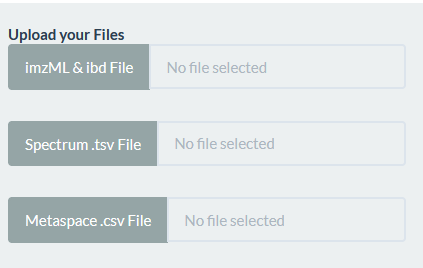

Loading the Data

After successfully loading the data the message “Upload complete” should appear.

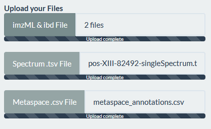

Data Loaded

When all files are fully loaded you can proceed and use the Peaks FWHM Estimation. To do this press Initialize as shown in the figure below.

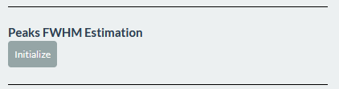

Peaks FWHM Estimation

A progress bar will appear at the bottom right of the app.

When the data has been processed and FWHM has been estimated, a plot will appear showing the approximation.

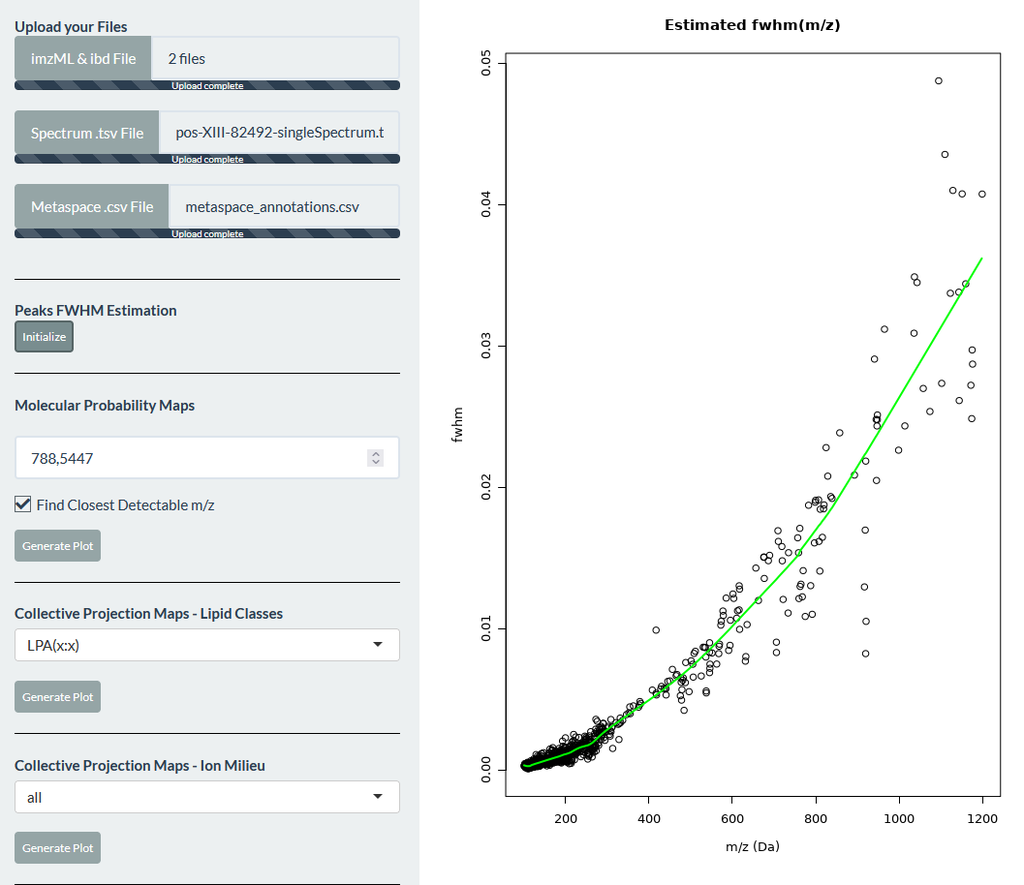

FWHM Estimation Completed

## 3.2 Molecular Probability Maps (MPM)

After entering the desired mass press “Generate Plot” and wait until the plots are generated.

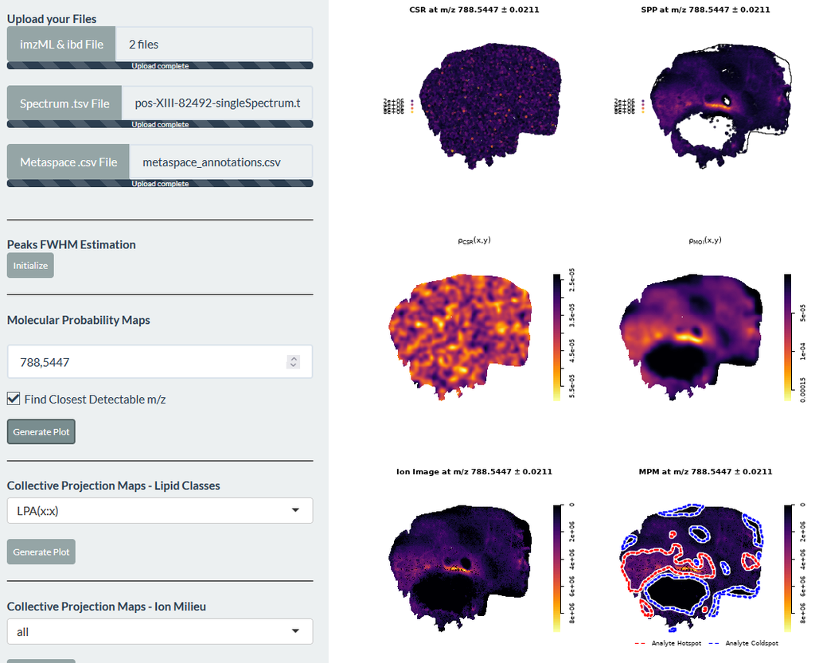

Molecular Probability Maps (MPM)

## 3.3 Collective Projection Maps (CPM)

The three different Collective Projection Maps (CPMs) that can be generted are:

1. Lipid Classes
2. Ion Milleu
3. Lipid Saturation

### 3.3.1 Lipid Classes

For Lipid Class generation one can choose a lipid from the dropdown menu before pressing “Generate Plot”.

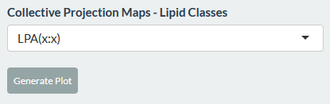

Lipid Classes Generation

After the generation is completed, plot similar to the one below is displayed.

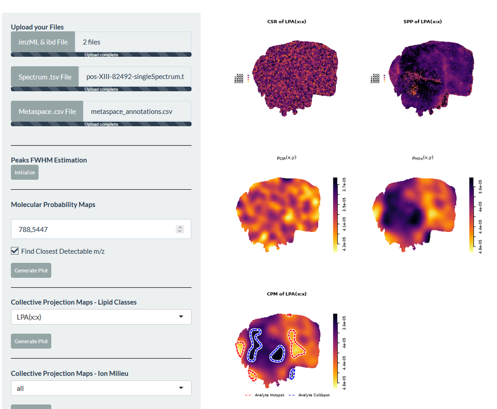

Lipid Classes Output

### 3.3.2 Ion Milleu

For Ion Milleu generation one can choose between `all, M+K, M+Na and M+H` from the dropdown menu before pressing “Generate Plot”.

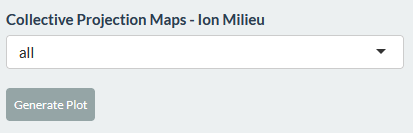

Ion Milleu Generation

After the generation is completed, plot similar to the one below is displayed.

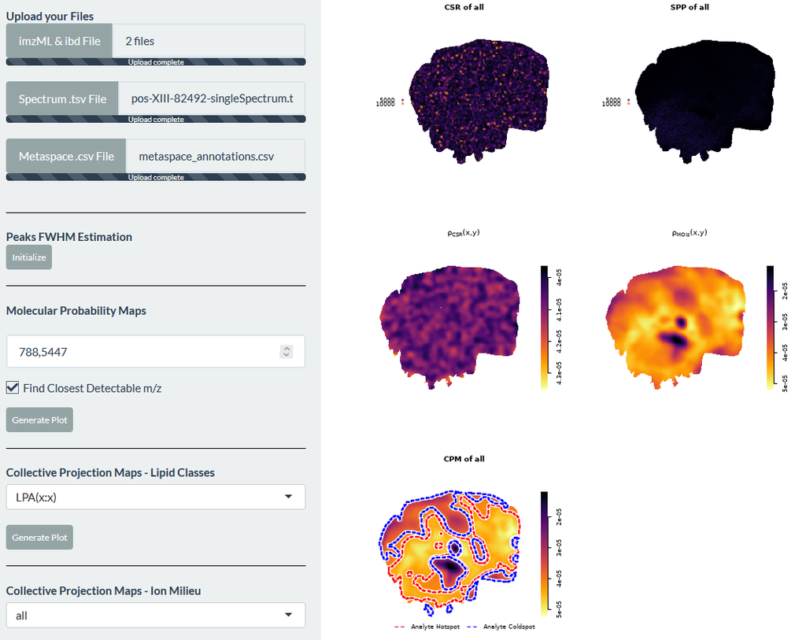

Ion Milleu Output

### 3.3.3 Lipid Saturation

For Lipid Saturation generation one can choose between `all, sat., mono., di. and poly.` from the dropdown menu before pressing “Generate Plot”.

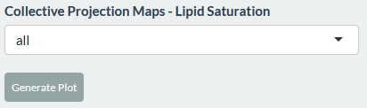

Lipid Saturation Generation

After the generation is completed, plot similar to the one below is displayed.

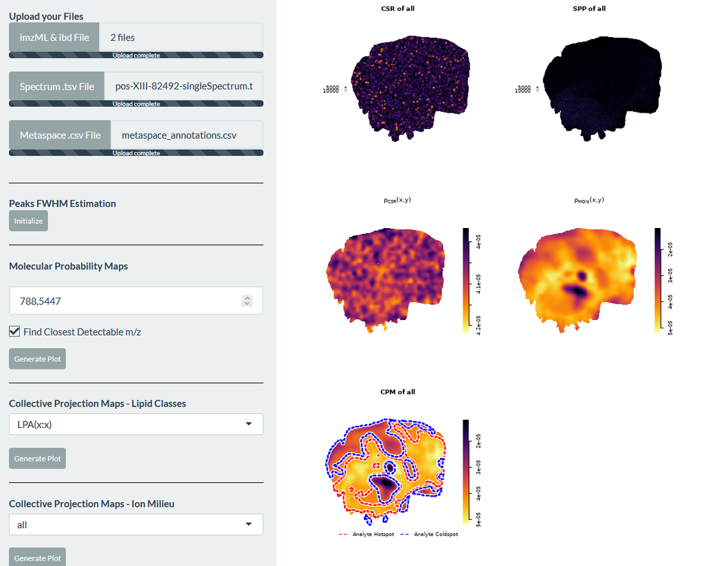

Lipid Saturation Output

## 3.4 Spatial Numeric Manipulation Maps